# Kunal-Applied-Statistics-Submission

#### 1. Import the necessary libraries

```python
import numpy as np
import pandas as pd
import seaborn as sns
import matplotlib.pyplot as plt
import copy
import statsmodels.api as sm
import scipy.stats as stats
from sklearn.preprocessing import LabelEncoder
sns.set(color_codes=True)
%matplotlib inline
```

#### 2. Read the data as a dataframe

```python
df = pd.read_csv('insurance.csv')
```

```python
# Display top 5 records
df.head()
```

|  | age | sex | bmi | children | smoker | region | charges |
| --- | --- | --- | --- | --- | --- | --- | --- |
| 0 | 19 | female | 27.900 | 0 | yes | southwest | 16884.92400 |
| 1 | 18 | male | 33.770 | 1 | no | southeast | 1725.55230 |
| 2 | 28 | male | 33.000 | 3 | no | southeast | 4449.46200 |
| 3 | 33 | male | 22.705 | 0 | no | northwest | 21984.47061 |
| 4 | 32 | male | 28.880 | 0 | no | northwest | 3866.85520 |

### 3. Perform basic EDA which should include the following and print out your insights at every step.

#### a. Shape of the data

```python
# Display shape of input dataframe
df.shape
```

```
(1338, 7)
```

#### b. Data type of each attribute

```python
# Display data types of variables
df.info()
```

```
<class 'pandas.core.frame.DataFrame'>
RangeIndex: 1338 entries, 0 to 1337
Data columns (total 7 columns):
age         1338 non-null int64
sex         1338 non-null object
bmi         1338 non-null float64
children    1338 non-null int64
smoker      1338 non-null object
region      1338 non-null object
charges     1338 non-null float64
dtypes: float64(2), int64(2), object(3)
memory usage: 73.2+ KB
```

#### c. Checking the presence of missing values

```python
# Summarize null values(missing values) in dataset
df.isna().sum()
```

```
age         0
sex         0
bmi         0
children    0
smoker      0
region      0
charges     0
dtype: int64
```

#### d. 5 point summary of numerical attributes

```python
# Five point summary of all continuous(numerical) variables
df.describe()
```

|  | age | bmi | children | charges |
| --- | --- | --- | --- | --- |
| count | 1338.000000 | 1338.000000 | 1338.000000 | 1338.000000 |
| mean | 39.207025 | 30.663397 | 1.094918 | 13270.422265 |
| std | 14.049960 | 6.098187 | 1.205493 | 12110.011237 |
| min | 18.000000 | 15.960000 | 0.000000 | 1121.873900 |
| 25% | 27.000000 | 26.296250 | 0.000000 | 4740.287150 |
| 50% | 39.000000 | 30.400000 | 1.000000 | 9382.033000 |
| 75% | 51.000000 | 34.693750 | 2.000000 | 16639.912515 |
| max | 64.000000 | 53.130000 | 5.000000 | 63770.428010 |

#### e. Distribution of ‘bmi’, ‘age’ and ‘charges’ columns.

```
[Text(0.5,1,'Distribution of bmi')]
```

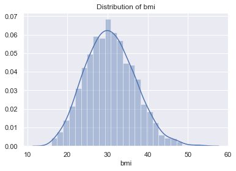

```python
# Distribution plot of bmi
sns.distplot(df['bmi']).set(title = 'Distribution of bmi')
```

```
[Text(0.5,1,'Distribution of age')]
```

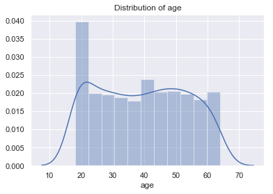

```python
# Distribution plot of age
sns.distplot(df['age']).set(title = 'Distribution of age')
```

```
[Text(0.5,1,'Distribution of charges')]
```

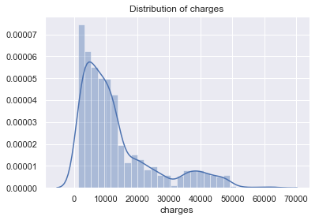

```python
# Distribution plot of charges
sns.distplot(df['charges']).set(title = 'Distribution of charges')
```

#### f. Measure of skewness of ‘bmi’, ‘age’ and ‘charges’ columns

```python
# Measure skewness of all continuous variables except children
df1 = pd.DataFrame(df, columns = ['bmi', 'age', 'charges'])
df1.skew(axis = 0, skipna = True)
```

```
bmi        0.284047
age        0.055673
charges    1.515880
dtype: float64
```

#### g. Checking the presence of outliers in ‘bmi’, ‘age’ and ‘charges columns

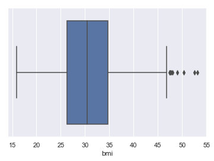

```python
# Detecting outliers via plots
sns.boxplot(x=df1['bmi'])
```

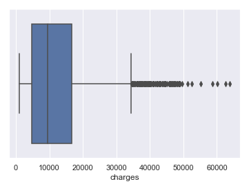

```python
# Detecting outliers via plots
sns.boxplot(x=df1['charges'])
```

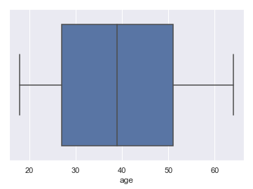

```python
# Detecting outliers via plots
sns.boxplot(x=df1['age'])
```

#### Inferring on the basis of boxplots of these variables, we can conclude that bmi have apparent outliers and charges have significatnt outliers.

```python
# Finding out IQR for age, bmi and charges variables.
Q1 = df1.quantile(0.25)
Q3 = df1.quantile(0.75)
IQR = Q3 - Q1
print(IQR)
```

```
bmi            8.397500
age           24.000000
charges    11899.625365
dtype: float64
```

```python
# Removing outliers
df_cleaned = df1[~((df1 < (Q1 - 1.5 * IQR)) |(df1 > (Q3 + 1.5 * IQR))).any(axis=1)]
```

```python
# Displaying shape before and after removing outliers
print("Shape with outliers: ", df1.shape)
print("Shape without outliers: ", df_cleaned.shape)
```

```
Shape with outliers:  (1338, 3)
Shape without outliers:  (1193, 3)
```

#### h. Distribution of categorical columns

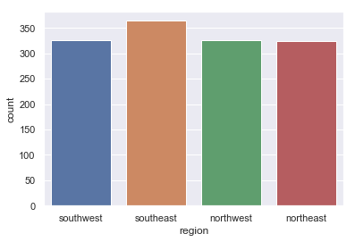

```python
sns.countplot(df['region'])
```

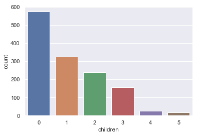

```python
sns.countplot(df['children'])
```

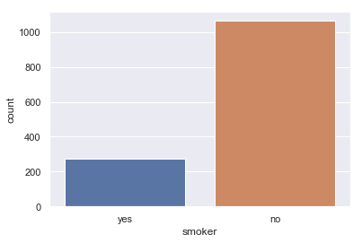

```python
sns.countplot(df['smoker'])
```

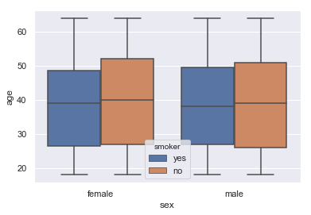

```python
# Relationship of categorical variable(sex, smoker) with age
sns.boxplot(x = df['sex'], y = df['age'], hue = df['smoker'])
```

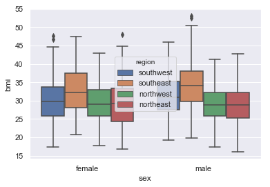

```python
# Relationship of categorical variable(sex, region) with bmi
sns.boxplot(x = df['sex'], y = df['bmi'], hue = df['region'])
```

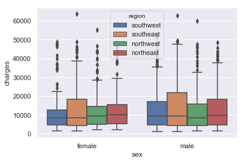

```python
# Relationship of categorical variable(sex, region) with charges
sns.boxplot(x = df['sex'], y = df['charges'], hue = df['region'])
```

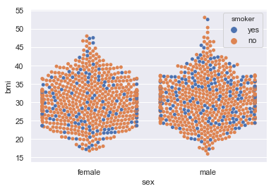

```python
# Relationship of categorical variable(sex, smoker) with bmi
sns.swarmplot(x = df['sex'], y = df['bmi'], hue = df['smoker'])
```

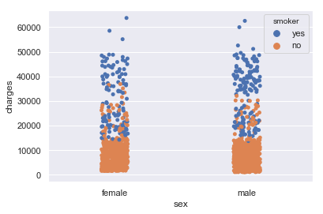

```python
# Relationship of categorical variable(sex, smoker) with charges
sns.stripplot(x = df['sex'], y = df['charges'], hue = df['smoker'])
```

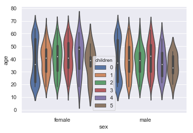

```python
# Relationship of categorical variable(sex, children) with bmi
sns.violinplot(x = df['sex'], y = df['age'], hue = df['children'])
```

#### i. Pair plot that includes all the columns of the data frame

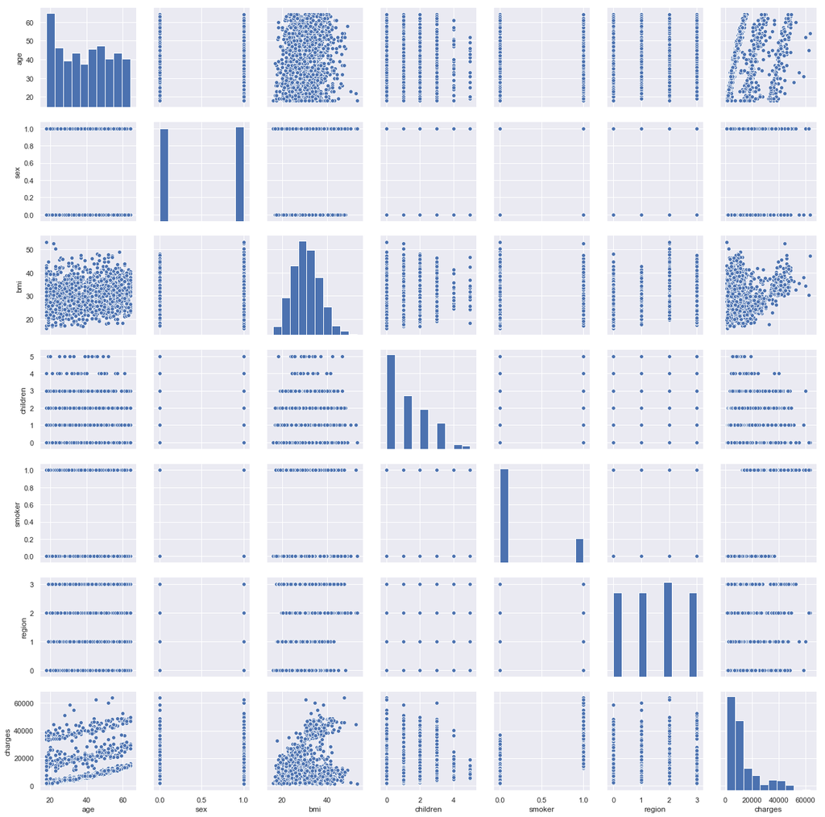

```python
df_transformed = copy.deepcopy(df)
df_transformed.loc[:,['sex', 'smoker', 'region']] = df_transformed.loc[:,['sex', 'smoker', 'region']].apply(LabelEncoder().fit_transform)
sns.pairplot(df_transformed)  #pairplot
plt.show()
```

#### From the pair plots, it can be inferred that charges for smokers are more than non smokers. Also, charges and ages have a slight linear relationship.

## Do charges of people who smoke differ significantly from the people who don't?

```
no     1064
yes     274
Name: smoker, dtype: int64
```

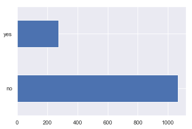

```python
print(df['smoker'].value_counts())
df['smoker'].value_counts().plot.barh()
```

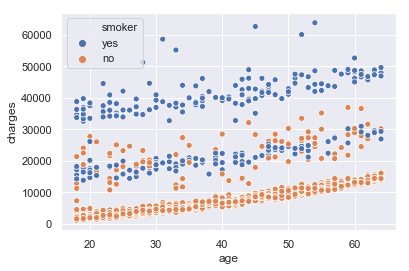

```python
sns.scatterplot(y = df['charges'], x = df['age'], hue = df['smoker'])
```

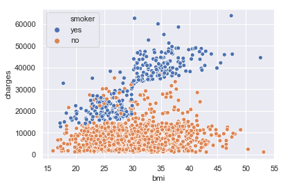

```python
sns.scatterplot(y = df['charges'], x = df['bmi'], hue = df['smoker'])
```

#### Visually the difference between charges of smokers and charges of non-smokers is significant, charges with respect to smokers are on a higher side.

### Establising results statistically

A p-value or probability value is the measure of statistical model wherein null hypothesis is accepted or rejected based on the measure of p-value.

```python
charges_of_smoker = np.array(df[df['smoker']=='yes'].charges)
charges_of_non_smoker = np.array(df[df['smoker']=='no'].charges)

t, p_value  = stats.ttest_ind(charges_of_smoker,charges_of_non_smoker, axis = 0)

if p_value < 0.05:  # Setting our significance level at 5%
    print(f'Alternate Hypothesis: Difference in charges ({p_value}) < 0.05')
else:
    print(f'Null Hypothesis: No difference in charges ({p_value}) > 0.05')
```

```
Alternate Hypothesis: Difference in charges (8.271435842177219e-283) < 0.05
```

## Does bmi of males differ significantly from that of females?

```
male      676
female    662
Name: sex, dtype: int64
```

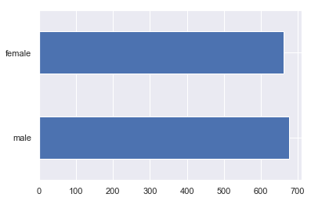

```python
print(df['sex'].value_counts())
df['sex'].value_counts().plot.barh()
```

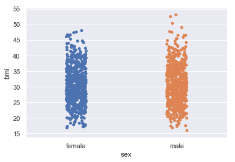

```python
sns.stripplot( df['sex'], df['bmi'], jitter=True)
```

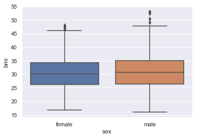

```python
sns.boxplot( df['sex'], df['bmi'])
```

#### Visually, there is no significant differences in bmi with respect to sex, but male has a few outliers or extreme data points.

### Establising results statistically

A p-value or probability value is the measure of statistical model wherein null hypothesis is accepted or rejected based on the measure of p-value.

```python
bmi_of_female = np.array(df[df['sex']=='female'].bmi)
bmi_of_male = np.array(df[df['sex']=='male'].bmi)

t, p_value  = stats.ttest_ind(bmi_of_female,bmi_of_male, axis = 0)

if p_value < 0.05:  # Setting our significance level at 5%
    print(f'Alternate Hypothesis: Difference in bmi with respect to sex({p_value}) < 0.05')
else:
    print(f'Null Hypothesis: No difference in bmi with respect to sex ({p_value}) > 0.05')
```

```
Null Hypothesis: No difference in bmi with respect to sex (0.08997637178984932) > 0.05
```

## Is the proportion of smokers significantly different in different genders?

```python
female_smoker = df[(df['sex']=='female') & (df['smoker'] == 'yes')]
female_non_smoker = df[(df['sex']=='female') & (df['smoker'] == 'no')]
print(f'No of female smokers: {len(female_smoker)}' )
print(f'No of female non smokers: {len(female_non_smoker)}' )

male_smoker = df[(df['sex']=='male') & (df['smoker'] == 'yes')]
male_non_smoker = df[(df['sex']=='male') & (df['smoker'] == 'no')]
print(f'No of male smokers: {len(male_smoker)}' )
print(f'No of male non smokers: {len(male_non_smoker)}')


#df['sex'].value_counts().plot.barh()
```

```
No of female smokers: 115
No of female non smokers: 547
No of male smokers: 159
No of male non smokers: 517
```

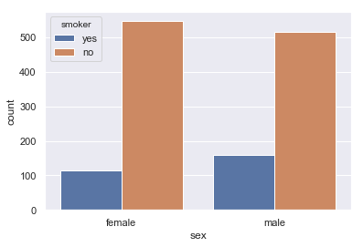

```python
sns.countplot(df['sex'], hue = df['smoker'])
```

```python
crosstab = pd.crosstab(df['sex'],df['smoker'])  # Contingency table of sex and smoker attributes

chi, p_value, dof, expected =  stats.chi2_contingency(crosstab)

if p_value < 0.05:  # Setting our significance level at 5%
    print(f'Gender has an effect as the p_value ({p_value.round(3)}) < 0.05')
else:
    print(f'Gender has no effect as the p_value ({p_value.round(3)}) > 0.05')
crosstab
```

```
Gender has an effect as the p_value (0.007) < 0.05
```

| smoker sex | no | yes |
| --- | --- | --- |
| female | 547 | 115 |
| male | 517 | 159 |

## Is the distribution of bmi across women with no children, one child and two children, the same?

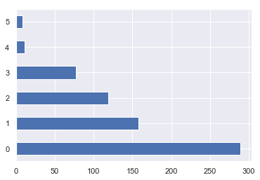

```python
female = df[df['sex']=='female']
female['children'].value_counts().plot.barh()
```

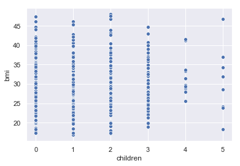

```python
sns.scatterplot(female['children'], female['bmi'])
```

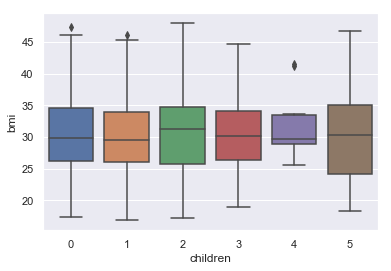

```python
sns.boxplot(female['children'], female['bmi'])
```

#### Visually, it can be inferred that there seems to be a uniform distribution for 0,1 and 2 no of child/children.

```python
zero = female[female.children == 0]['bmi']
one = female[female.children == 1]['bmi']
two = female[female.children == 2]['bmi']

f_stat, p_value = stats.f_oneway(zero,one,two)
```

```python
if p_value < 0.05:  # Setting our significance level at 5%
    print(f'No of children affects bmi of woman as the p_value ({p_value.round(3)}) < 0.05')
else:
    print(f'No of children does not affects bmi of woman as the p_value ({p_value.round(3)}) > 0.05')
```

```
No of children does not affects bmi of woman as the p_value (0.716) > 0.05
```